# Results: investigate dataset.sas

| Obs | No_show | Gender | Age | Scholarship | Hipertension | Diabetes | Alcoholism | Handcap | SMS_received |
| --- | --- | --- | --- | --- | --- | --- | --- | --- | --- |
| 1 | Showed up | F | 62 | 0 | 1 | 0 | 0 | 0 | 0 |
| 2 | Showed up | M | 56 | 0 | 0 | 0 | 0 | 0 | 0 |
| 3 | Showed up | F | 62 | 0 | 0 | 0 | 0 | 0 | 0 |
| 4 | Showed up | F | 8 | 0 | 0 | 0 | 0 | 0 | 0 |
| 5 | Showed up | F | 56 | 0 | 1 | 1 | 0 | 0 | 0 |

The CONTENTS Procedure

| Data Set Name | WORK.NOSHOW | Observations | 110527 |
| --- | --- | --- | --- |
| Member Type | DATA | Variables | 9 |
| Engine | V9 | Indexes | 0 |
| Created | 10/01/2018 20:05:14 | Observation Length | 80 |
| Last Modified | 10/01/2018 20:05:14 | Deleted Observations | 0 |
| Protection |  | Compressed | NO |
| Data Set Type |  | Sorted | NO |
| Label |  |  |  |
| Data Representation | SOLARIS_X86_64, LINUX_X86_64, ALPHA_TRU64, LINUX_IA64 |  |  |
| Encoding | utf-8 Unicode (UTF-8) |  |  |

[output not shown]

| Alphabetic List of Variables and Attributes # | Alphabetic List of Variables and Attributes Variable | Alphabetic List of Variables and Attributes Type | Alphabetic List of Variables and Attributes Len | Alphabetic List of Variables and Attributes Format | Alphabetic List of Variables and Attributes Informat |
| --- | --- | --- | --- | --- | --- |
| 3 | Age | Num | 8 | BEST12. | BEST32. |
| 7 | Alcoholism | Num | 8 | BEST12. | BEST32. |
| 6 | Diabetes | Num | 8 | BEST12. | BEST32. |
| 2 | Gender | Char | 1 | $1. | $1. |
| 8 | Handcap | Num | 8 | BEST12. | BEST32. |
| 5 | Hipertension | Num | 8 | BEST12. | BEST32. |
| 1 | No_show | Char | 20 | $20. | $3. |
| 9 | SMS_received | Num | 8 | BEST12. | BEST32. |
| 4 | Scholarship | Num | 8 | BEST12. | BEST32. |

The MEANS Procedure

| Variable | N | N Miss |
| --- | --- | --- |
| Age Scholarship Hypertension Diabetes Alcoholism Handicap SMS_received | 110527 110527 110527 110527 110527 110527 110527 | 0 0 0 0 0 0 0 |

The FREQ Procedure

| No_show | Frequency | Percent | Cumulative Frequency | Cumulative Percent |
| --- | --- | --- | --- | --- |
| Showed up | 88208 | 79.81 | 88208 | 79.81 |
| not showed up | 22319 | 20.19 | 110527 | 100.00 |

| Gender | Frequency | Percent | Cumulative Frequency | Cumulative Percent |
| --- | --- | --- | --- | --- |
| F | 71840 | 65.00 | 71840 | 65.00 |
| M | 38687 | 35.00 | 110527 | 100.00 |

The FREQ Procedure

| No_show | Frequency |
| --- | --- |
| Not Missing | 110527 |

| Gender | Frequency |
| --- | --- |
| Not Missing | 110527 |

| Age | Frequency |
| --- | --- |
| Not Missing | 110527 |

| Scholarship | Frequency |
| --- | --- |
| Not Missing | 110527 |

| Hypertension | Frequency |
| --- | --- |
| Not Missing | 110527 |

| Diabetes | Frequency |
| --- | --- |
| Not Missing | 110527 |

| Alcoholism | Frequency |
| --- | --- |
| Not Missing | 110527 |

| Handicap | Frequency |
| --- | --- |
| Not Missing | 110527 |

| SMS_received | Frequency |
| --- | --- |
| Not Missing | 110527 |

The MEANS Procedure

| Analysis Variable : Age N | Analysis Variable : Age Mean | Analysis Variable : Age Std Dev | Analysis Variable : Age Minimum | Analysis Variable : Age Maximum |
| --- | --- | --- | --- | --- |
| 110527 | 37.0888742 | 23.1102050 | -1.0000000 | 115.0000000 |

The FREQ Procedure

| Gender | Frequency | Percent | Cumulative Frequency | Cumulative Percent |
| --- | --- | --- | --- | --- |
| F | 71840 | 65.00 | 71840 | 65.00 |
| M | 38687 | 35.00 | 110527 | 100.00 |

The UNIVARIATE Procedure

Variable: Age

| Moments |  |  |  |
| --- | --- | --- | --- |
| N | 110527 | Sum Weights | 110527 |
| Mean | 37.0888742 | Sum Observations | 4099322 |
| Std Deviation | 23.110205 | Variance | 534.081573 |
| Skewness | 0.12165802 | Kurtosis | -0.9522674 |
| Uncorrected SS | 211069138 | Corrected SS | 59029900 |
| Coeff Variation | 62.3103436 | Std Error Mean | 0.06951357 |

| Basic Statistical Measures Location | Basic Statistical Measures Location | Basic Statistical Measures Variability | Basic Statistical Measures Variability |
| --- | --- | --- | --- |
| Mean | 37.08887 | Std Deviation | 23.11020 |
| Median | 37.00000 | Variance | 534.08157 |
| Mode | 0.00000 | Range | 116.00000 |
|  |  | Interquartile Range | 37.00000 |

| Tests for Location: Mu0=0 Test | Tests for Location: Mu0=0 Statistic | Tests for Location: Mu0=0 Statistic | Tests for Location: Mu0=0 p Value | Tests for Location: Mu0=0 p Value |
| --- | --- | --- | --- | --- |
| Student's t | t | 533.5487 | Pr > \|t\| | <.0001 |
| Sign | M | 53493 | Pr >= \|M\| | <.0001 |
| Signed Rank | S | 2.8616E9 | Pr >= \|S\| | <.0001 |

| Quantiles (Definition 5) Level | Quantiles (Definition 5) Quantile |
| --- | --- |
| 100% Max | 115 |
| 99% | 86 |
| 95% | 75 |
| 90% | 68 |
| 75% Q3 | 55 |
| 50% Median | 37 |
| 25% Q1 | 18 |
| 10% | 5 |
| 5% | 1 |
| 1% | 0 |
| 0% Min | -1 |

| Extreme Observations Lowest Value | Extreme Observations Lowest Obs | Extreme Observations Highest Value | Extreme Observations Highest Obs |
| --- | --- | --- | --- |
| -1 | 99833 | 115 | 63913 |
| 0 | 110508 | 115 | 63916 |
| 0 | 110461 | 115 | 68128 |
| 0 | 110455 | 115 | 76285 |
| 0 | 110347 | 115 | 97667 |

The FREQ Procedure

| Gender | Frequency | Percent | Cumulative Frequency | Cumulative Percent |
| --- | --- | --- | --- | --- |
| F | 71840 | 65.00 | 71840 | 65.00 |
| M | 38687 | 35.00 | 110527 | 100.00 |

| Hypertension | Frequency | Percent | Cumulative Frequency | Cumulative Percent |
| --- | --- | --- | --- | --- |
| 0 | 88726 | 80.28 | 88726 | 80.28 |
| 1 | 21801 | 19.72 | 110527 | 100.00 |

| Diabetes | Frequency | Percent | Cumulative Frequency | Cumulative Percent |
| --- | --- | --- | --- | --- |
| 0 | 102584 | 92.81 | 102584 | 92.81 |
| 1 | 7943 | 7.19 | 110527 | 100.00 |

| No_show | Frequency | Percent | Cumulative Frequency | Cumulative Percent |
| --- | --- | --- | --- | --- |
| Showed up | 88208 | 79.81 | 88208 | 79.81 |
| not showed up | 22319 | 20.19 | 110527 | 100.00 |

The MEANS Procedure

| Variable | N | Mean | Std Dev | Minimum | Maximum |
| --- | --- | --- | --- | --- | --- |
| Age Scholarship Hypertension Diabetes Alcoholism Handicap SMS_received | 110527 110527 110527 110527 110527 110527 110527 | 37.0888742 0.0982656 0.1972459 0.0718648 0.0303998 0.0222480 0.3210256 | 23.1102050 0.2976748 0.3979213 0.2582651 0.1716856 0.1615427 0.4668727 | -1.0000000 0 0 0 0 0 0 | 115.0000000 1.0000000 1.0000000 1.0000000 1.0000000 4.0000000 1.0000000 |

| Obs | No_show | Gender | Age | Scholarship | Hypertension | Diabetes | Alcoholism | Handicap | SMS_received |
| --- | --- | --- | --- | --- | --- | --- | --- | --- | --- |
| 99833 | Showed up | F | -1 | 0 | 0 | 0 | 0 | 0 | 0 |

The MEANS Procedure

| Analysis Variable : Age N | Analysis Variable : Age Mean | Analysis Variable : Age Std Dev | Analysis Variable : Age Minimum | Analysis Variable : Age Maximum |
| --- | --- | --- | --- | --- |
| 110526 | 37.0892188 | 23.1100255 | 0 | 115.0000000 |

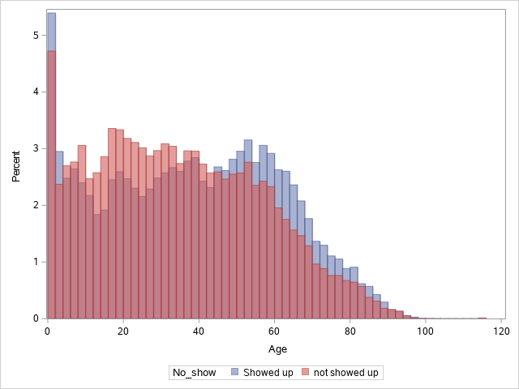

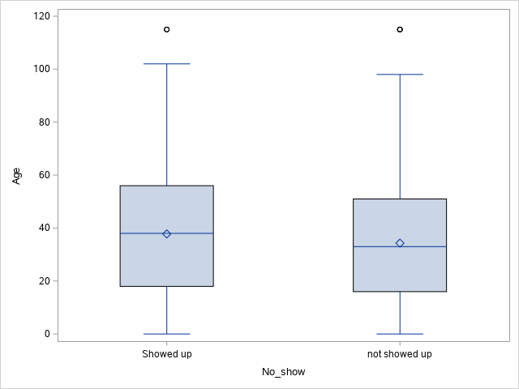

[figure not shown]

The TTEST Procedure

Variable: Age

| No_show | Method | N | Mean | Std Dev | Std Err | Minimum | Maximum |
| --- | --- | --- | --- | --- | --- | --- | --- |
| Showed up |  | 88207 | 37.7905 | 23.3386 | 0.0786 | 0 | 115.0 |
| not showed up |  | 22319 | 34.3177 | 21.9659 | 0.1470 | 0 | 115.0 |
| Diff (1-2) | Pooled |  | 3.4728 | 23.0680 | 0.1728 |  |  |
| Diff (1-2) | Satterthwaite |  | 3.4728 |  | 0.1667 |  |  |

| No_show | Method | Mean | 95% CL Mean |  | Std Dev | 95% CL Std Dev |  |
| --- | --- | --- | --- | --- | --- | --- | --- |
| Showed up |  | 37.7905 | 37.6365 | 37.9445 | 23.3386 | 23.2302 | 23.4481 |
| not showed up |  | 34.3177 | 34.0295 | 34.6059 | 21.9659 | 21.7641 | 22.1716 |
| Diff (1-2) | Pooled | 3.4728 | 3.1341 | 3.8116 | 23.0680 | 22.9723 | 23.1646 |
| Diff (1-2) | Satterthwaite | 3.4728 | 3.1461 | 3.7996 |  |  |  |

| Method | Variances | DF | t Value | Pr > \|t\| |
| --- | --- | --- | --- | --- |
| Pooled | Equal | 110524 | 20.09 | <.0001 |
| Satterthwaite | Unequal | 36143 | 20.83 | <.0001 |

| Equality of Variances Method | Equality of Variances Num DF | Equality of Variances Den DF | Equality of Variances F Value | Equality of Variances Pr > F |
| --- | --- | --- | --- | --- |
| Folded F | 88206 | 22318 | 1.13 | <.0001 |

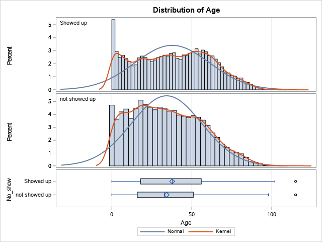

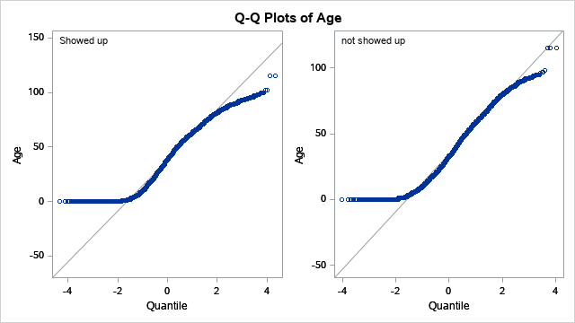

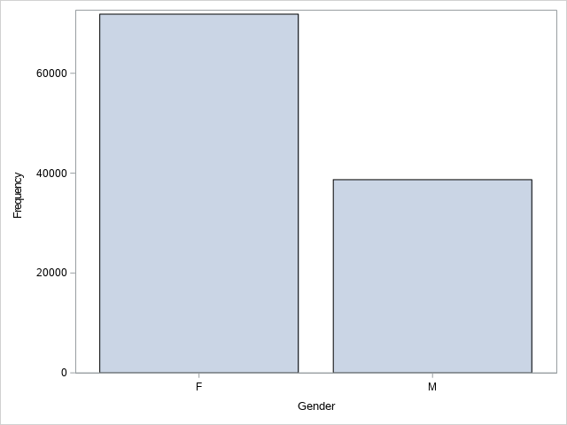

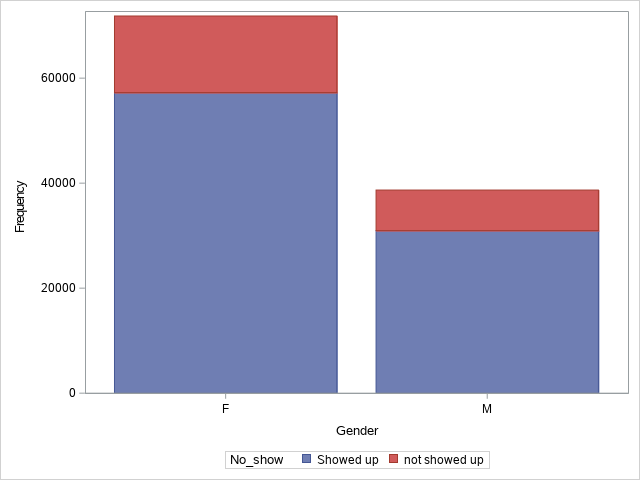

The FREQ Procedure

| Frequency Percent Row Pct Col Pct |
| --- |

| Table of No_show by Gender No_show | Table of No_show by Gender Gender F | Table of No_show by Gender Gender M | Table of No_show by Gender Gender Total |
| --- | --- | --- | --- |
| Showed up | 57245 51.79 64.90 79.69 | 30962 28.01 35.10 80.03 | 88207 79.81 |
| not showed up | 14594 13.20 65.39 20.31 | 7725 6.99 34.61 19.97 | 22319 20.19 |
| Total | 71839 65.00 | 38687 35.00 | 110526 100.00 |

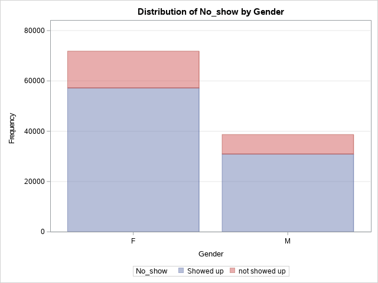

The FREQ Procedure

| Frequency Percent Row Pct Col Pct |
| --- |

| Table of No_show by Gender No_show | Table of No_show by Gender Gender F | Table of No_show by Gender Gender M | Table of No_show by Gender Gender Total |
| --- | --- | --- | --- |
| Showed up | 57245 51.79 64.90 79.69 | 30962 28.01 35.10 80.03 | 88207 79.81 |
| not showed up | 14594 13.20 65.39 20.31 | 7725 6.99 34.61 19.97 | 22319 20.19 |
| Total | 71839 65.00 | 38687 35.00 | 110526 100.00 |

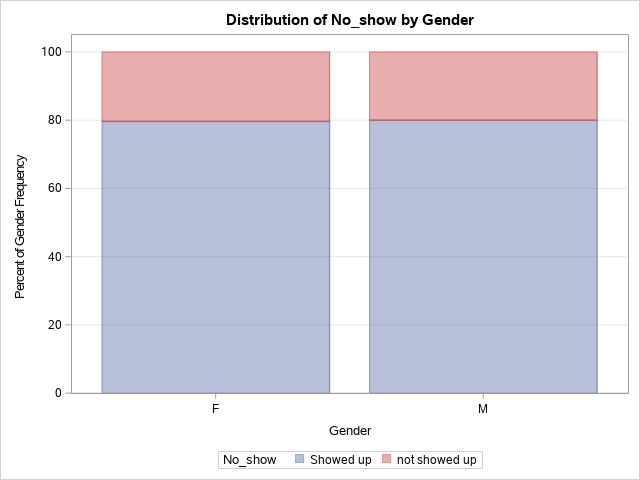

The FREQ Procedure

| Frequency Percent Row Pct Col Pct |
| --- |

| Table of Gender by No_show Gender | Table of Gender by No_show No_show Showed up | Table of Gender by No_show No_show not showed up | Table of Gender by No_show No_show Total |
| --- | --- | --- | --- |
| F | 57245 51.79 79.69 64.90 | 14594 13.20 20.31 65.39 | 71839 65.00 |
| M | 30962 28.01 80.03 35.10 | 7725 6.99 19.97 34.61 | 38687 35.00 |
| Total | 88207 79.81 | 22319 20.19 | 110526 100.00 |

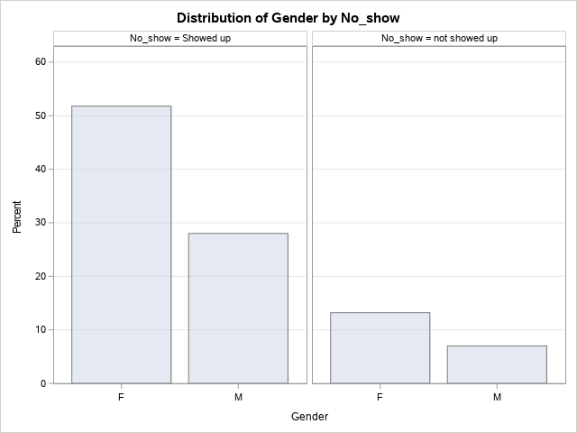

Statistics for Table of Gender by No_show

| Statistic | DF | Value | Prob |
| --- | --- | --- | --- |
| Chi-Square | 1 | 1.8779 | 0.1706 |
| Likelihood Ratio Chi-Square | 1 | 1.8804 | 0.1703 |
| Continuity Adj. Chi-Square | 1 | 1.8565 | 0.1730 |
| Mantel-Haenszel Chi-Square | 1 | 1.8779 | 0.1706 |
| Phi Coefficient |  | -0.0041 |  |
| Contingency Coefficient |  | 0.0041 |  |
| Cramer's V |  | -0.0041 |  |

| Fisher's Exact Test |  |
| --- | --- |
| Cell (1,1) Frequency (F) | 57245 |
| Left-sided Pr <= F | 0.0865 |
| Right-sided Pr >= F | 0.9160 |
| Table Probability (P) | 0.0025 |
| Two-sided Pr <= P | 0.1717 |

Sample Size = 110526

The FREQ Procedure

| Frequency Percent Row Pct Col Pct |
| --- |

| Table of Gender by No_show Gender | Table of Gender by No_show No_show Showed up | Table of Gender by No_show No_show not showed up | Table of Gender by No_show No_show Total |
| --- | --- | --- | --- |
| F | 57245 51.79 79.69 64.90 | 14594 13.20 20.31 65.39 | 71839 65.00 |
| M | 30962 28.01 80.03 35.10 | 7725 6.99 19.97 34.61 | 38687 35.00 |
| Total | 88207 79.81 | 22319 20.19 | 110526 100.00 |

Statistics for Table of Gender by No_show

| Statistic | DF | Value | Prob |
| --- | --- | --- | --- |
| Chi-Square | 1 | 1.8779 | 0.1706 |
| Likelihood Ratio Chi-Square | 1 | 1.8804 | 0.1703 |
| Continuity Adj. Chi-Square | 1 | 1.8565 | 0.1730 |
| Mantel-Haenszel Chi-Square | 1 | 1.8779 | 0.1706 |
| Phi Coefficient |  | -0.0041 |  |
| Contingency Coefficient |  | 0.0041 |  |
| Cramer's V |  | -0.0041 |  |

| Fisher's Exact Test |  |
| --- | --- |
| Cell (1,1) Frequency (F) | 57245 |
| Left-sided Pr <= F | 0.0865 |
| Right-sided Pr >= F | 0.9160 |
| Table Probability (P) | 0.0025 |
| Two-sided Pr <= P | 0.1717 |

Sample Size = 110526

The FREQ Procedure

| Frequency Percent Row Pct Col Pct |
| --- |

| Table of No_show by Scholarship No_show | Table of No_show by Scholarship Scholarship 0 | Table of No_show by Scholarship Scholarship 1 | Table of No_show by Scholarship Scholarship Total |
| --- | --- | --- | --- |
| Showed up | 79924 72.31 90.61 80.19 | 8283 7.49 9.39 76.26 | 88207 79.81 |
| not showed up | 19741 17.86 88.45 19.81 | 2578 2.33 11.55 23.74 | 22319 20.19 |
| Total | 99665 90.17 | 10861 9.83 | 110526 100.00 |

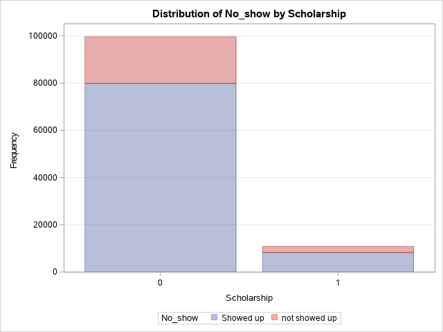

The FREQ Procedure

| Frequency Percent Row Pct Col Pct |
| --- |

| Table of Scholarship by No_show Scholarship | Table of Scholarship by No_show No_show Showed up | Table of Scholarship by No_show No_show not showed up | Table of Scholarship by No_show No_show Total |
| --- | --- | --- | --- |
| 0 | 79924 72.31 80.19 90.61 | 19741 17.86 19.81 88.45 | 99665 90.17 |
| 1 | 8283 7.49 76.26 9.39 | 2578 2.33 23.74 11.55 | 10861 9.83 |
| Total | 88207 79.81 | 22319 20.19 | 110526 100.00 |

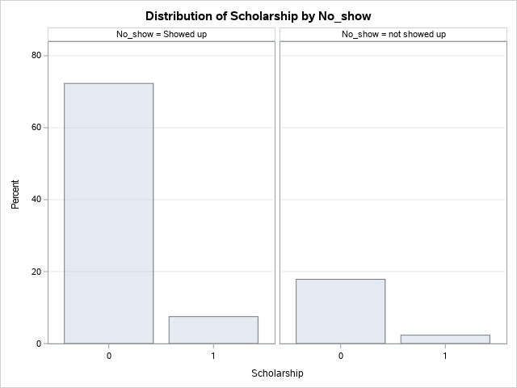

Statistics for Table of Scholarship by No_show

| Statistic | DF | Value | Prob |
| --- | --- | --- | --- |
| Chi-Square | 1 | 93.8106 | <.0001 |
| Likelihood Ratio Chi-Square | 1 | 90.4791 | <.0001 |
| Continuity Adj. Chi-Square | 1 | 93.5670 | <.0001 |
| Mantel-Haenszel Chi-Square | 1 | 93.8098 | <.0001 |
| Phi Coefficient |  | 0.0291 |  |
| Contingency Coefficient |  | 0.0291 |  |
| Cramer's V |  | 0.0291 |  |

| Fisher's Exact Test |  |
| --- | --- |
| Cell (1,1) Frequency (F) | 79924 |
| Left-sided Pr <= F | 1.0000 |
| Right-sided Pr >= F | <.0001 |
| Table Probability (P) | <.0001 |
| Two-sided Pr <= P | <.0001 |

Sample Size = 110526

The FREQ Procedure

| Frequency Percent Row Pct Col Pct |
| --- |

| Table of No_show by Hypertension No_show | Table of No_show by Hypertension Hypertension 0 | Table of No_show by Hypertension Hypertension 1 | Table of No_show by Hypertension Hypertension Total |
| --- | --- | --- | --- |
| Showed up | 70178 63.49 79.56 79.10 | 18029 16.31 20.44 82.70 | 88207 79.81 |
| not showed up | 18547 16.78 83.10 20.90 | 3772 3.41 16.90 17.30 | 22319 20.19 |
| Total | 88725 80.28 | 21801 19.72 | 110526 100.00 |

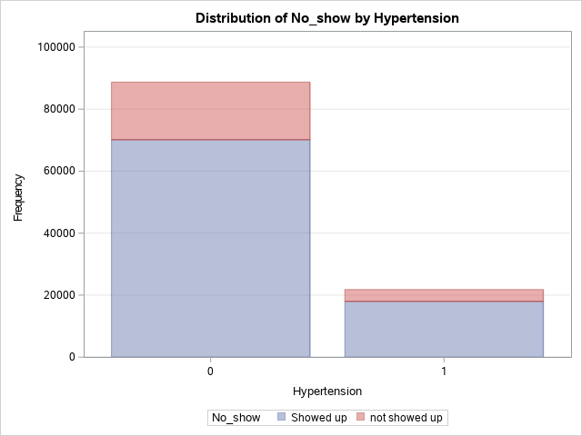

The FREQ Procedure

| Frequency Percent Row Pct Col Pct |
| --- |

| Table of Hypertension by No_show Hypertension | Table of Hypertension by No_show No_show Showed up | Table of Hypertension by No_show No_show not showed up | Table of Hypertension by No_show No_show Total |
| --- | --- | --- | --- |
| 0 | 70178 63.49 79.10 79.56 | 18547 16.78 20.90 83.10 | 88725 80.28 |
| 1 | 18029 16.31 82.70 20.44 | 3772 3.41 17.30 16.90 | 21801 19.72 |
| Total | 88207 79.81 | 22319 20.19 | 110526 100.00 |

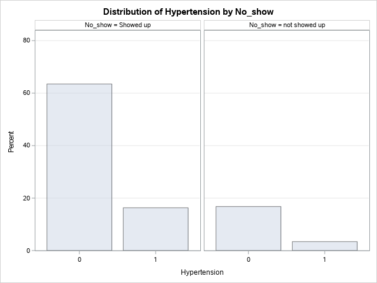

Statistics for Table of Hypertension by No_show

| Statistic | DF | Value | Prob |
| --- | --- | --- | --- |
| Chi-Square | 1 | 140.8920 | <.0001 |
| Likelihood Ratio Chi-Square | 1 | 145.0281 | <.0001 |
| Continuity Adj. Chi-Square | 1 | 140.6686 | <.0001 |
| Mantel-Haenszel Chi-Square | 1 | 140.8907 | <.0001 |
| Phi Coefficient |  | -0.0357 |  |
| Contingency Coefficient |  | 0.0357 |  |
| Cramer's V |  | -0.0357 |  |

| Fisher's Exact Test |  |
| --- | --- |
| Cell (1,1) Frequency (F) | 70178 |
| Left-sided Pr <= F | <.0001 |
| Right-sided Pr >= F | 1.0000 |
| Table Probability (P) | <.0001 |
| Two-sided Pr <= P | <.0001 |

Sample Size = 110526

The FREQ Procedure

| Frequency Percent Row Pct Col Pct |
| --- |

| Table of No_show by Diabetes No_show | Table of No_show by Diabetes Diabetes 0 | Table of No_show by Diabetes Diabetes 1 | Table of No_show by Diabetes Diabetes Total |
| --- | --- | --- | --- |
| Showed up | 81694 73.91 92.62 79.64 | 6513 5.89 7.38 82.00 | 88207 79.81 |
| not showed up | 20889 18.90 93.59 20.36 | 1430 1.29 6.41 18.00 | 22319 20.19 |
| Total | 102583 92.81 | 7943 7.19 | 110526 100.00 |

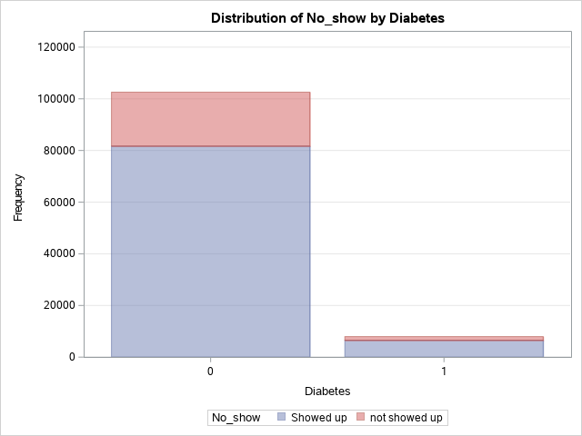

The FREQ Procedure

| Frequency Percent Row Pct Col Pct |
| --- |

| Table of Diabetes by No_show Diabetes | Table of Diabetes by No_show No_show Showed up | Table of Diabetes by No_show No_show not showed up | Table of Diabetes by No_show No_show Total |
| --- | --- | --- | --- |
| 0 | 81694 73.91 79.64 92.62 | 20889 18.90 20.36 93.59 | 102583 92.81 |
| 1 | 6513 5.89 82.00 7.38 | 1430 1.29 18.00 6.41 | 7943 7.19 |
| Total | 88207 79.81 | 22319 20.19 | 110526 100.00 |

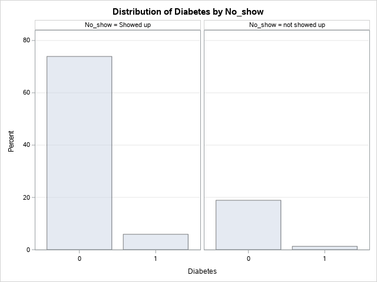

Statistics for Table of Diabetes by No_show

| Statistic | DF | Value | Prob |
| --- | --- | --- | --- |
| Chi-Square | 1 | 25.4729 | <.0001 |
| Likelihood Ratio Chi-Square | 1 | 26.1477 | <.0001 |
| Continuity Adj. Chi-Square | 1 | 25.3267 | <.0001 |
| Mantel-Haenszel Chi-Square | 1 | 25.4727 | <.0001 |
| Phi Coefficient |  | -0.0152 |  |
| Contingency Coefficient |  | 0.0152 |  |
| Cramer's V |  | -0.0152 |  |

| Fisher's Exact Test |  |
| --- | --- |
| Cell (1,1) Frequency (F) | 81694 |
| Left-sided Pr <= F | <.0001 |
| Right-sided Pr >= F | 1.0000 |
| Table Probability (P) | <.0001 |
| Two-sided Pr <= P | <.0001 |

Sample Size = 110526

The FREQ Procedure

| Frequency Percent Row Pct Col Pct |
| --- |

| Table of No_show by Alcoholism No_show | Table of No_show by Alcoholism Alcoholism 0 | Table of No_show by Alcoholism Alcoholism 1 | Table of No_show by Alcoholism Alcoholism Total |
| --- | --- | --- | --- |
| Showed up | 85524 77.38 96.96 79.81 | 2683 2.43 3.04 79.85 | 88207 79.81 |
| not showed up | 21642 19.58 96.97 20.19 | 677 0.61 3.03 20.15 | 22319 20.19 |
| Total | 107166 96.96 | 3360 3.04 | 110526 100.00 |

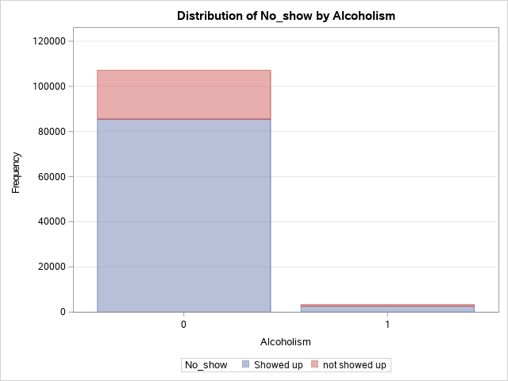

The FREQ Procedure

| Frequency Percent Row Pct Col Pct |
| --- |

| Table of Alcoholism by No_show Alcoholism | Table of Alcoholism by No_show No_show Showed up | Table of Alcoholism by No_show No_show not showed up | Table of Alcoholism by No_show No_show Total |
| --- | --- | --- | --- |
| 0 | 85524 77.38 79.81 96.96 | 21642 19.58 20.19 96.97 | 107166 96.96 |
| 1 | 2683 2.43 79.85 3.04 | 677 0.61 20.15 3.03 | 3360 3.04 |
| Total | 88207 79.81 | 22319 20.19 | 110526 100.00 |

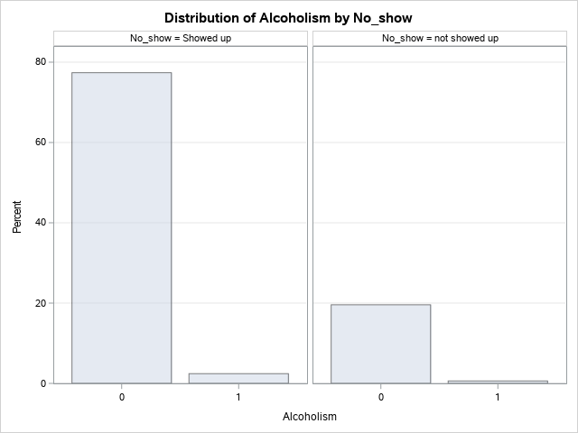

Statistics for Table of Alcoholism by No_show

| Statistic | DF | Value | Prob |
| --- | --- | --- | --- |
| Chi-Square | 1 | 0.0043 | 0.9478 |
| Likelihood Ratio Chi-Square | 1 | 0.0043 | 0.9478 |
| Continuity Adj. Chi-Square | 1 | 0.0019 | 0.9652 |
| Mantel-Haenszel Chi-Square | 1 | 0.0043 | 0.9478 |
| Phi Coefficient |  | -0.0002 |  |
| Contingency Coefficient |  | 0.0002 |  |
| Cramer's V |  | -0.0002 |  |

| Fisher's Exact Test |  |
| --- | --- |
| Cell (1,1) Frequency (F) | 85524 |
| Left-sided Pr <= F | 0.4842 |
| Right-sided Pr >= F | 0.5332 |
| Table Probability (P) | 0.0174 |
| Two-sided Pr <= P | 0.9652 |

Sample Size = 110526

The FREQ Procedure

| Frequency Percent Row Pct Col Pct |
| --- |

| Table of No_show by Handicap No_show | Table of No_show by Handicap Handicap 0 | Table of No_show by Handicap Handicap 1 | Table of No_show by Handicap Handicap 2 | Table of No_show by Handicap Handicap 3 | Table of No_show by Handicap Handicap 4 | Table of No_show by Handicap Handicap Total |
| --- | --- | --- | --- | --- | --- | --- |
| Showed up | 86373 78.15 97.92 79.76 | 1676 1.52 1.90 82.08 | 146 0.13 0.17 79.78 | 10 0.01 0.01 76.92 | 2 0.00 0.00 66.67 | 88207 79.81 |
| not showed up | 21912 19.83 98.18 20.24 | 366 0.33 1.64 17.92 | 37 0.03 0.17 20.22 | 3 0.00 0.01 23.08 | 1 0.00 0.00 33.33 | 22319 20.19 |
| Total | 108285 97.97 | 2042 1.85 | 183 0.17 | 13 0.01 | 3 0.00 | 110526 100.00 |

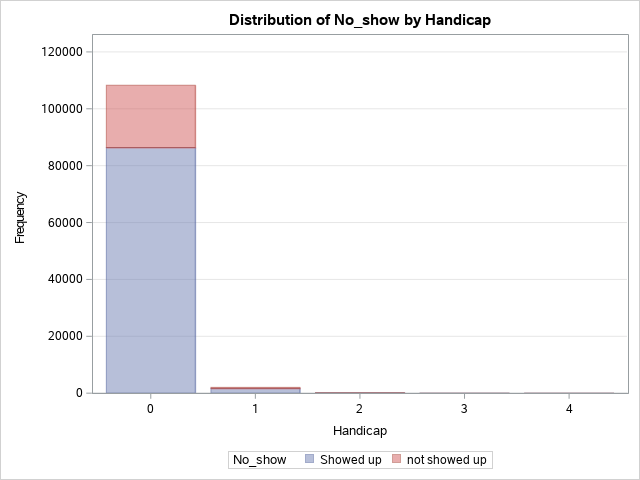

The FREQ Procedure

| Frequency Percent Row Pct Col Pct |
| --- |

| Table of Handicap by No_show Handicap | Table of Handicap by No_show No_show Showed up | Table of Handicap by No_show No_show not showed up | Table of Handicap by No_show No_show Total |
| --- | --- | --- | --- |
| 0 | 86373 78.15 79.76 97.92 | 21912 19.83 20.24 98.18 | 108285 97.97 |
| 1 | 1676 1.52 82.08 1.90 | 366 0.33 17.92 1.64 | 2042 1.85 |
| 2 | 146 0.13 79.78 0.17 | 37 0.03 20.22 0.17 | 183 0.17 |
| 3 | 10 0.01 76.92 0.01 | 3 0.00 23.08 0.01 | 13 0.01 |
| 4 | 2 0.00 66.67 0.00 | 1 0.00 33.33 0.00 | 3 0.00 |
| Total | 88207 79.81 | 22319 20.19 | 110526 100.00 |

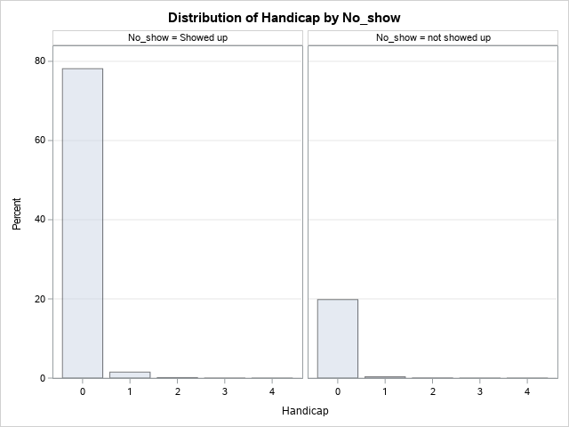

Statistics for Table of Handicap by No_show

| Statistic | DF | Value | Prob |
| --- | --- | --- | --- |
| Chi-Square | 4 | 7.0356 | 0.1340 |
| Likelihood Ratio Chi-Square | 4 | 7.1894 | 0.1262 |
| Mantel-Haenszel Chi-Square | 1 | 4.0815 | 0.0434 |
| Phi Coefficient |  | 0.0080 |  |
| Contingency Coefficient |  | 0.0080 |  |
| Cramer's V |  | 0.0080 |  |

WARNING: 30% of the cells have expected counts less than 5. Chi-Square may not be a valid test.

Sample Size = 110526

The FREQ Procedure

| Frequency Percent Row Pct Col Pct |
| --- |

| Table of No_show by SMS_received No_show | Table of No_show by SMS_received SMS_received 0 | Table of No_show by SMS_received SMS_received 1 | Table of No_show by SMS_received SMS_received Total |
| --- | --- | --- | --- |
| Showed up | 62509 56.56 70.87 83.30 | 25698 23.25 29.13 72.43 | 88207 79.81 |
| not showed up | 12535 11.34 56.16 16.70 | 9784 8.85 43.84 27.57 | 22319 20.19 |
| Total | 75044 67.90 | 35482 32.10 | 110526 100.00 |

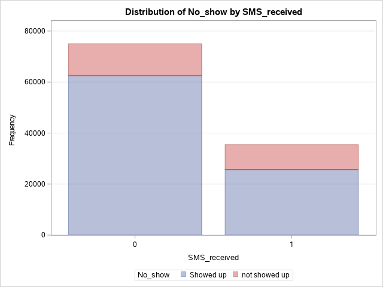

The FREQ Procedure

| Frequency Percent Row Pct Col Pct |
| --- |

| Table of SMS_received by No_show SMS_received | Table of SMS_received by No_show No_show Showed up | Table of SMS_received by No_show No_show not showed up | Table of SMS_received by No_show No_show Total |
| --- | --- | --- | --- |
| 0 | 62509 56.56 83.30 70.87 | 12535 11.34 16.70 56.16 | 75044 67.90 |
| 1 | 25698 23.25 72.43 29.13 | 9784 8.85 27.57 43.84 | 35482 32.10 |
| Total | 88207 79.81 | 22319 20.19 | 110526 100.00 |

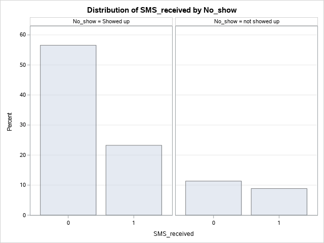

Statistics for Table of SMS_received by No_show

| Statistic | DF | Value | Prob |
| --- | --- | --- | --- |
| Chi-Square | 1 | 1766.6503 | <.0001 |
| Likelihood Ratio Chi-Square | 1 | 1702.3529 | <.0001 |
| Continuity Adj. Chi-Square | 1 | 1765.9758 | <.0001 |
| Mantel-Haenszel Chi-Square | 1 | 1766.6343 | <.0001 |
| Phi Coefficient |  | 0.1264 |  |
| Contingency Coefficient |  | 0.1254 |  |
| Cramer's V |  | 0.1264 |  |

| Fisher's Exact Test |  |
| --- | --- |
| Cell (1,1) Frequency (F) | 62509 |
| Left-sided Pr <= F | 1.0000 |
| Right-sided Pr >= F | <.0001 |
| Table Probability (P) | <.0001 |
| Two-sided Pr <= P | <.0001 |

Sample Size = 110526

The LOGISTIC Procedure

| Model Information |  |
| --- | --- |
| Data Set | WORK.NOSHOW |
| Response Variable | No_show |
| Number of Response Levels | 2 |
| Model | binary logit |
| Optimization Technique | Fisher's scoring |

| Number of Observations Read | 110526 |
| --- | --- |
| Number of Observations Used | 110526 |

| Response Profile Ordered Value | Response Profile No_show | Response Profile Total Frequency |
| --- | --- | --- |
| 1 | Showed up | 88207 |
| 2 | not showed up | 22319 |

Probability modeled is No_show='Showed up'.

Backward Elimination Procedure

| Class Level Information Class | Class Level Information Value | Class Level Information Design Variables | Class Level Information Design Variables | Class Level Information Design Variables | Class Level Information Design Variables | Class Level Information Design Variables |
| --- | --- | --- | --- | --- | --- | --- |
| Gender | F | 1 | 0 |  |  |  |
|  | M | 0 | 1 |  |  |  |
| Scholarship | 0 | 1 | 0 |  |  |  |
|  | 1 | 0 | 1 |  |  |  |
| Hypertension | 0 | 1 | 0 |  |  |  |
|  | 1 | 0 | 1 |  |  |  |
| Diabetes | 0 | 1 | 0 |  |  |  |
|  | 1 | 0 | 1 |  |  |  |
| Alcoholism | 0 | 1 | 0 |  |  |  |
|  | 1 | 0 | 1 |  |  |  |
| Handicap | 0 | 1 | 0 | 0 | 0 | 0 |
|  | 1 | 0 | 1 | 0 | 0 | 0 |
|  | 2 | 0 | 0 | 1 | 0 | 0 |
|  | 3 | 0 | 0 | 0 | 1 | 0 |
|  | 4 | 0 | 0 | 0 | 0 | 1 |
| SMS_received | 0 | 1 | 0 |  |  |  |
|  | 1 | 0 | 1 |  |  |  |

Step 0. The following effects were entered:

Intercept Gender Scholarship Hypertension Diabetes Alcoholism Handicap SMS_received Age

| Model Convergence Status |
| --- |
| Convergence criterion (GCONV=1E-8) satisfied. |

| Model Fit Statistics Criterion | Model Fit Statistics Intercept Only | Model Fit Statistics Intercept and Covariates |
| --- | --- | --- |
| AIC | 111207.16 | 109012.10 |
| SC | 111216.77 | 109137.07 |
| -2 Log L | 111205.16 | 108986.10 |

| Testing Global Null Hypothesis: BETA=0 Test | Testing Global Null Hypothesis: BETA=0 Chi-Square | Testing Global Null Hypothesis: BETA=0 DF | Testing Global Null Hypothesis: BETA=0 Pr > ChiSq |
| --- | --- | --- | --- |
| Likelihood Ratio | 2219.0549 | 12 | <.0001 |
| Score | 2269.1165 | 12 | <.0001 |
| Wald | . | 11 | . |

Step 1. Effect Handicap is removed:

| Model Convergence Status |
| --- |
| Convergence criterion (GCONV=1E-8) satisfied. |

| Model Fit Statistics Criterion | Model Fit Statistics Intercept Only | Model Fit Statistics Intercept and Covariates |
| --- | --- | --- |
| AIC | 111207.16 | 109003.03 |
| SC | 111216.77 | 109079.93 |
| -2 Log L | 111205.16 | 108987.03 |

| Testing Global Null Hypothesis: BETA=0 Test | Testing Global Null Hypothesis: BETA=0 Chi-Square | Testing Global Null Hypothesis: BETA=0 DF | Testing Global Null Hypothesis: BETA=0 Pr > ChiSq |
| --- | --- | --- | --- |
| Likelihood Ratio | 2218.1285 | 7 | <.0001 |
| Score | 2268.1236 | 7 | <.0001 |
| Wald | 2216.0617 | 7 | <.0001 |

| Residual Chi-Square Test Chi-Square | Residual Chi-Square Test DF | Residual Chi-Square Test Pr > ChiSq |
| --- | --- | --- |
| 0.9715 | 4 | 0.9141 |

Step 2. Effect Gender is removed:

| Model Convergence Status |
| --- |
| Convergence criterion (GCONV=1E-8) satisfied. |

| Model Fit Statistics Criterion | Model Fit Statistics Intercept Only | Model Fit Statistics Intercept and Covariates |
| --- | --- | --- |
| AIC | 111207.16 | 109002.24 |
| SC | 111216.77 | 109069.53 |
| -2 Log L | 111205.16 | 108988.24 |

| Testing Global Null Hypothesis: BETA=0 Test | Testing Global Null Hypothesis: BETA=0 Chi-Square | Testing Global Null Hypothesis: BETA=0 DF | Testing Global Null Hypothesis: BETA=0 Pr > ChiSq |
| --- | --- | --- | --- |
| Likelihood Ratio | 2216.9143 | 6 | <.0001 |
| Score | 2267.1341 | 6 | <.0001 |
| Wald | 2215.0999 | 6 | <.0001 |

| Residual Chi-Square Test Chi-Square | Residual Chi-Square Test DF | Residual Chi-Square Test Pr > ChiSq |
| --- | --- | --- |
| 2.1825 | 5 | 0.8234 |

Note:No (additional) effects met the 0.05 significance level for removal from the model.

| Summary of Backward Elimination Step | Summary of Backward Elimination Effect Removed | Summary of Backward Elimination DF | Summary of Backward Elimination Number In | Summary of Backward Elimination Wald Chi-Square | Summary of Backward Elimination Pr > ChiSq |
| --- | --- | --- | --- | --- | --- |
| 1 | Handicap | 0 | 7 | . | . |
| 2 | Gender | 1 | 6 | 1.2130 | 0.2707 |

| Type 3 Analysis of Effects Effect | Type 3 Analysis of Effects DF | Type 3 Analysis of Effects Wald Chi-Square | Type 3 Analysis of Effects Pr > ChiSq |
| --- | --- | --- | --- |
| Scholarship | 1 | 59.9809 | <.0001 |
| Hypertension | 1 | 7.5275 | 0.0061 |
| Diabetes | 1 | 6.2840 | 0.0122 |
| Alcoholism | 1 | 9.0783 | 0.0026 |
| SMS_received | 1 | 1771.9559 | <.0001 |
| Age | 1 | 279.7163 | <.0001 |

| Analysis of Maximum Likelihood Estimates Parameter | Analysis of Maximum Likelihood Estimates | Analysis of Maximum Likelihood Estimates DF | Analysis of Maximum Likelihood Estimates Estimate | Analysis of Maximum Likelihood Estimates Standard Error | Analysis of Maximum Likelihood Estimates Wald Chi-Square | Analysis of Maximum Likelihood Estimates Pr > ChiSq |
| --- | --- | --- | --- | --- | --- | --- |
| Intercept |  | 1 | 0.4021 | 0.0626 | 41.2734 | <.0001 |
| Scholarship | 0 | 1 | 0.1881 | 0.0243 | 59.9809 | <.0001 |
| Scholarship | 1 | 0 | 0 | . | . | . |
| Hypertension | 0 | 1 | -0.0674 | 0.0246 | 7.5275 | 0.0061 |
| Hypertension | 1 | 0 | 0 | . | . | . |
| Diabetes | 0 | 1 | 0.0855 | 0.0341 | 6.2840 | 0.0122 |
| Diabetes | 1 | 0 | 0 | . | . | . |
| Alcoholism | 0 | 1 | 0.1340 | 0.0445 | 9.0783 | 0.0026 |
| Alcoholism | 1 | 0 | 0 | . | . | . |
| SMS_received | 0 | 1 | 0.6504 | 0.0155 | 1771.9559 | <.0001 |
| SMS_received | 1 | 0 | 0 | . | . | . |
| Age |  | 1 | 0.00651 | 0.000389 | 279.7163 | <.0001 |

| Odds Ratio Estimates Effect | Odds Ratio Estimates Point Estimate | Odds Ratio Estimates 95% Wald Confidence Limits | Odds Ratio Estimates 95% Wald Confidence Limits |
| --- | --- | --- | --- |
| Scholarship 0 vs 1 | 1.207 | 1.151 | 1.266 |
| Hypertension 0 vs 1 | 0.935 | 0.891 | 0.981 |
| Diabetes 0 vs 1 | 1.089 | 1.019 | 1.165 |
| Alcoholism 0 vs 1 | 1.143 | 1.048 | 1.248 |
| SMS_received 0 vs 1 | 1.916 | 1.859 | 1.975 |
| Age | 1.007 | 1.006 | 1.007 |

| Association of Predicted Probabilities and Observed Responses |  |  |  |
| --- | --- | --- | --- |
| Percent Concordant | 59.5 | Somers' D | 0.193 |
| Percent Discordant | 40.1 | Gamma | 0.194 |
| Percent Tied | 0.4 | Tau-a | 0.062 |
| Pairs | 1968692033 | c | 0.597 |